# Can the models recover severe mortality at high DHW?

Event-held-out comparison of the formal benchmark and shape-aware candidates

# The candidate being tested

The shape-aware candidate is not a forced 50% mortality rule. It makes four specific changes and leaves the existing benchmark untouched:

- proportional Acropora cover is the primary community-susceptibility term;
- total preceding coral cover replaces the strongly correlated absolute Acropora-cover term;
- the response can steepen above 8 DHW and the DHW–Acropora interaction enters both mortality occurrence and positive magnitude;
- event identity is excluded from the ecological mean so it cannot absorb a relationship that must transfer to a future event.

The BRT additionally constrains DHW and proportional Acropora effects to be non-decreasing, gives each reef-year equal fitting weight, and tunes against overall, event-balanced, and high-DHW errors. The Bayesian model uses directional but non-binding ecological priors.

# Recommended production route

No single candidate wins for every observation programme. The recommended predictor therefore uses the best event-held-out route for each programme and does not ask a tree model to extrapolate beyond the largest DHW in its training data.

Programme-specific model routing rule

| Programme | Within observed DHW support | Beyond observed DHW support | Reason |
| --- | --- | --- | --- |
| LTMP benthic | Shape-aware ensemble | Shape-aware BRMS | Shape ensemble improves overall and severe-tail validation; use BRMS alone beyond tree training support. |
| Manta tow | Benchmark ensemble | Benchmark BRMS | Shape candidate worsens event-held-out calibration; retain the benchmark and drop its BRT outside support. |
| MMP inshore | Shape-aware BRMS | Shape-aware BRMS | Shape BRMS has the best overall, severe-tail, and 2024 event-held-out performance. |

This promotes the shape-aware ensemble for LTMP within support, retains the benchmark for manta tow, and promotes the shape-aware BRMS for MMP. BRMS alone is used beyond observed DHW support because boosted trees cannot extrapolate a new dose-response slope.

# Held-out predictive performance

Leave-one-event-out performance; lower error is better

| Programme | Model | n | RMSE | MAE | Predictive R2 | Observed - predicted | Severe-loss MAE | High-DHW MAE | High-DHW/Acropora MAE | 2020/22 MAE |
| --- | --- | --- | --- | --- | --- | --- | --- | --- | --- | --- |
| LTMP benthic | Recommended routed model | 199 | 0.128 | 0.080 | 0.408 | -0.006 | 0.212 | 0.136 | 0.203 | 0.051 |
| LTMP benthic | Shape-aware ensemble | 199 | 0.128 | 0.080 | 0.408 | -0.006 | 0.212 | 0.136 | 0.203 | 0.051 |
| LTMP benthic | Benchmark ensemble | 199 | 0.131 | 0.085 | 0.388 | 0.000 | 0.234 | 0.167 | 0.202 | 0.049 |
| LTMP benthic | Shape-aware BRMS | 199 | 0.134 | 0.082 | 0.357 | -0.011 | 0.212 | 0.165 | 0.264 | 0.052 |
| MMP inshore | Recommended routed model | 90 | 0.216 | 0.142 | 0.129 | 0.004 | 0.207 | 0.120 | 0.123 | 0.142 |
| MMP inshore | Shape-aware BRMS | 90 | 0.216 | 0.142 | 0.129 | 0.004 | 0.207 | 0.120 | 0.123 | 0.142 |
| MMP inshore | Shape-aware ensemble | 90 | 0.221 | 0.149 | 0.096 | 0.044 | 0.246 | 0.143 | 0.202 | 0.144 |
| MMP inshore | Benchmark ensemble | 90 | 0.246 | 0.174 | -0.121 | 0.060 | 0.297 | 0.206 | 0.344 | 0.150 |
| Manta tow | Benchmark ensemble | 248 | 0.141 | 0.105 | 0.169 | 0.011 | 0.221 | 0.128 | 0.109 | 0.073 |
| Manta tow | Recommended routed model | 248 | 0.141 | 0.105 | 0.169 | 0.011 | 0.221 | 0.128 | 0.109 | 0.073 |
| Manta tow | Shape-aware BRMS | 248 | 0.148 | 0.102 | 0.077 | 0.013 | 0.235 | 0.167 | 0.181 | 0.066 |
| Manta tow | Shape-aware ensemble | 248 | 0.149 | 0.105 | 0.060 | 0.008 | 0.234 | 0.168 | 0.181 | 0.073 |

Overall RMSE is retained because it measures GBR-wide average error, but it is not allowed to hide the severe tail. High-DHW/Acropora rows have at least 10 DHW and at least 70% proportional Acropora cover. Positive bias below means the model is still underpredicting mortality.

The high-tail versus low-event calibration trade-off

| Programme | Model | High-DHW observed - predicted | High-DHW/Acropora observed - predicted | 2020/22 observed - predicted |
| --- | --- | --- | --- | --- |
| LTMP benthic | Benchmark ensemble | 0.102 | 0.120 | -0.027 |
| LTMP benthic | Recommended routed model | -0.070 | -0.169 | -0.029 |
| Manta tow | Benchmark ensemble | 0.037 | 0.039 | -0.048 |
| Manta tow | Recommended routed model | 0.037 | 0.039 | -0.048 |
| MMP inshore | Benchmark ensemble | 0.148 | 0.336 | -0.150 |
| MMP inshore | Recommended routed model | -0.037 | -0.010 | -0.142 |

Calibration in each held-out event

| Programme | Model | Event | Observed mean | Predicted mean | Observed - predicted | RMSE |
| --- | --- | --- | --- | --- | --- | --- |
| LTMP benthic | Benchmark ensemble | 2016 | 0.183 | 0.168 | 0.016 | 0.179 |
| LTMP benthic | Benchmark ensemble | 2017 | 0.186 | 0.186 | 0.000 | 0.242 |
| LTMP benthic | Benchmark ensemble | 2020 | 0.023 | 0.052 | -0.029 | 0.091 |
| LTMP benthic | Benchmark ensemble | 2022 | 0.016 | 0.039 | -0.023 | 0.049 |
| LTMP benthic | Benchmark ensemble | 2024 | 0.113 | 0.089 | 0.024 | 0.121 |
| LTMP benthic | Recommended routed model | 2016 | 0.183 | 0.134 | 0.049 | 0.176 |
| LTMP benthic | Recommended routed model | 2017 | 0.186 | 0.180 | 0.006 | 0.231 |
| LTMP benthic | Recommended routed model | 2020 | 0.023 | 0.055 | -0.033 | 0.091 |
| LTMP benthic | Recommended routed model | 2022 | 0.016 | 0.041 | -0.025 | 0.049 |
| LTMP benthic | Recommended routed model | 2024 | 0.113 | 0.113 | -0.001 | 0.122 |
| Manta tow | Benchmark ensemble | 2016 | 0.145 | 0.134 | 0.012 | 0.129 |
| Manta tow | Benchmark ensemble | 2017 | 0.131 | 0.110 | 0.021 | 0.120 |
| Manta tow | Benchmark ensemble | 2020 | 0.011 | 0.074 | -0.063 | 0.076 |
| Manta tow | Benchmark ensemble | 2022 | 0.036 | 0.067 | -0.031 | 0.097 |
| Manta tow | Benchmark ensemble | 2024 | 0.191 | 0.107 | 0.084 | 0.195 |
| Manta tow | Recommended routed model | 2016 | 0.145 | 0.134 | 0.012 | 0.129 |
| Manta tow | Recommended routed model | 2017 | 0.131 | 0.110 | 0.021 | 0.120 |
| Manta tow | Recommended routed model | 2020 | 0.011 | 0.074 | -0.063 | 0.076 |
| Manta tow | Recommended routed model | 2022 | 0.036 | 0.067 | -0.031 | 0.097 |
| Manta tow | Recommended routed model | 2024 | 0.191 | 0.107 | 0.084 | 0.195 |
| MMP inshore | Benchmark ensemble | 2017 | 0.125 | 0.155 | -0.029 | 0.119 |
| MMP inshore | Benchmark ensemble | 2022 | 0.000 | 0.150 | -0.150 | 0.159 |
| MMP inshore | Benchmark ensemble | 2024 | 0.238 | 0.110 | 0.128 | 0.300 |
| MMP inshore | Recommended routed model | 2017 | 0.125 | 0.154 | -0.028 | 0.117 |
| MMP inshore | Recommended routed model | 2022 | 0.000 | 0.142 | -0.142 | 0.152 |
| MMP inshore | Recommended routed model | 2024 | 0.238 | 0.203 | 0.035 | 0.261 |

# Does 12 DHW now produce ecologically plausible mortality?

The production curves below use all five events for fitting. “Acropora dominated” means 90% proportional Acropora and 55% total pre-event coral cover; other attainable predictors are held at programme-specific medians. These are scenario predictions, not a replacement for held-out validation.

Production response at 12 DHW in an Acropora-dominated community

| Programme | Model | Mortality occurrence | Mortality when present | Expected mortality |
| --- | --- | --- | --- | --- |
| LTMP benthic | Shape-aware BRMS | 0.993 | 0.566 | 0.562 |
| LTMP benthic | Recommended routed model | 0.993 | 0.566 | 0.562 |
| LTMP benthic | Benchmark ensemble | 0.850 | 0.368 | 0.288 |
| MMP inshore | Shape-aware BRMS | 0.960 | 0.635 | 0.609 |
| MMP inshore | Recommended routed model | 0.960 | 0.635 | 0.609 |
| MMP inshore | Benchmark ensemble | 0.907 | 0.458 | 0.416 |
| Manta tow | Shape-aware BRMS | 0.987 | 0.571 | 0.563 |
| Manta tow | Benchmark ensemble | 0.862 | 0.295 | 0.254 |
| Manta tow | Recommended routed model | 0.865 | 0.293 | 0.254 |

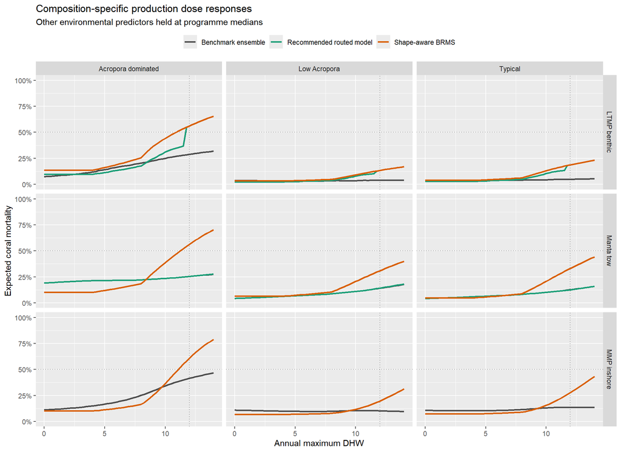

# Where does held-out underprediction remain?

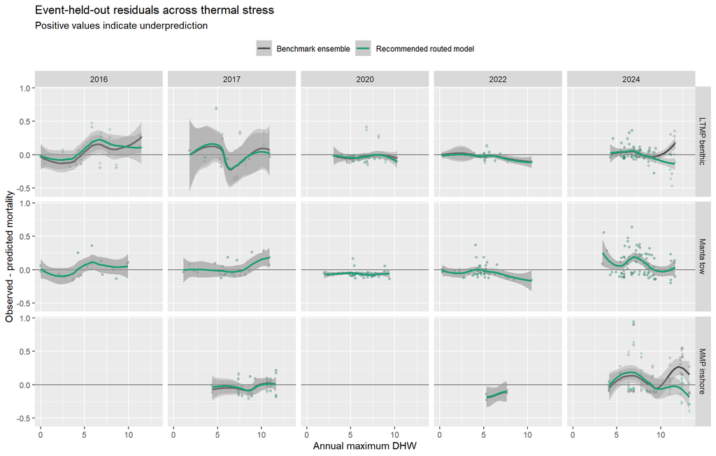

# Ensemble and sampling diagnostics

Candidate production weights estimated from event-held-out predictions

| Programme | n | Shape-aware BRMS weight | Shape-aware BRT weight |
| --- | --- | --- | --- |
| LTMP benthic | 199 | 0.586 | 0.414 |
| Manta tow | 248 | 0.846 | 0.154 |
| MMP inshore | 90 | 0.818 | 0.182 |

Shape-aware BRMS sampling diagnostics

| Programme | Event | Maximum R-hat | Minimum bulk ESS | Minimum tail ESS | Divergences | Tree-depth hits |
| --- | --- | --- | --- | --- | --- | --- |
| Manta tow | 2016 | 1.006 | 357.127 | 396.873 | 0 | 0 |
| Manta tow | 2017 | 1.008 | 381.359 | 520.048 | 0 | 0 |
| Manta tow | 2020 | 1.005 | 938.637 | 1761.894 | 0 | 0 |
| Manta tow | 2022 | 1.006 | 241.855 | 541.738 | 0 | 0 |
| Manta tow | 2024 | 1.006 | 400.582 | 578.487 | 0 | 0 |
| LTMP benthic | 2016 | 1.005 | 280.548 | 404.207 | 0 | 0 |
| LTMP benthic | 2017 | 1.008 | 868.458 | 1519.904 | 0 | 0 |
| LTMP benthic | 2020 | 1.006 | 634.330 | 1160.730 | 0 | 0 |
| LTMP benthic | 2022 | 1.004 | 781.731 | 1474.721 | 0 | 0 |
| LTMP benthic | 2024 | 1.007 | 170.282 | 326.501 | 0 | 0 |
| MMP inshore | 2017 | 1.004 | 1567.829 | 2150.283 | 0 | 0 |
| MMP inshore | 2022 | 1.005 | 646.312 | 815.587 | 0 | 0 |
| MMP inshore | 2024 | 1.005 | 688.342 | 928.851 | 0 | 0 |

Promotion requires more than producing a steeper curve. The candidate must improve held-out high-DHW and severe-loss calibration, retain acceptable overall error, avoid inflating the low-mortality 2020/22 events, and pass all sampling diagnostics. Any failure remains visible rather than being averaged away by the production scenario.